# IODS course project

# LOGISTICAL REGRESSION

```r
library(ggplot2)
library(dplyr)
library(tidyr)
library(boot)
```

```r
alc <- read.csv("create_alc.csv", TRUE, ",")
summary(alc)
```

```
##        X          school   sex          age        address famsize
##  Min.   :  1.00   GP:342   F:198   Min.   :15.00   R: 81   GT3:278
##  1st Qu.: 96.25   MS: 40   M:184   1st Qu.:16.00   U:301   LE3:104
##  Median :191.50                    Median :17.00
##  Mean   :191.50                    Mean   :16.59
##  3rd Qu.:286.75                    3rd Qu.:17.00
##  Max.   :382.00                    Max.   :22.00
##  Pstatus      Medu            Fedu             Mjob           Fjob
##  A: 38   Min.   :0.000   Min.   :0.000   at_home : 53   at_home : 16
##  T:344   1st Qu.:2.000   1st Qu.:2.000   health  : 33   health  : 17
##          Median :3.000   Median :3.000   other   :138   other   :211
##          Mean   :2.806   Mean   :2.565   services: 96   services:107
##          3rd Qu.:4.000   3rd Qu.:4.000   teacher : 62   teacher : 31
##          Max.   :4.000   Max.   :4.000
##         reason    nursery   internet    guardian     traveltime
##  course    :140   no : 72   no : 58   father: 91   Min.   :1.000
##  home      :110   yes:310   yes:324   mother:275   1st Qu.:1.000
##  other     : 34                       other : 16   Median :1.000
##  reputation: 98                                    Mean   :1.448
##                                                    3rd Qu.:2.000
##                                                    Max.   :4.000
##    studytime        failures      schoolsup famsup     paid     activities
##  Min.   :1.000   Min.   :0.0000   no :331   no :144   no :205   no :181
##  1st Qu.:1.000   1st Qu.:0.0000   yes: 51   yes:238   yes:177   yes:201
##  Median :2.000   Median :0.0000
##  Mean   :2.037   Mean   :0.2016
##  3rd Qu.:2.000   3rd Qu.:0.0000
##  Max.   :4.000   Max.   :3.0000
##  higher    romantic      famrel         freetime        goout
##  no : 18   no :261   Min.   :1.000   Min.   :1.00   Min.   :1.000
##  yes:364   yes:121   1st Qu.:4.000   1st Qu.:3.00   1st Qu.:2.000
##                      Median :4.000   Median :3.00   Median :3.000
##                      Mean   :3.937   Mean   :3.22   Mean   :3.113
##                      3rd Qu.:5.000   3rd Qu.:4.00   3rd Qu.:4.000
##                      Max.   :5.000   Max.   :5.00   Max.   :5.000
##       Dalc            Walc           health         absences
##  Min.   :1.000   Min.   :1.000   Min.   :1.000   Min.   : 0.0
##  1st Qu.:1.000   1st Qu.:1.000   1st Qu.:3.000   1st Qu.: 1.0
##  Median :1.000   Median :2.000   Median :4.000   Median : 3.0
##  Mean   :1.482   Mean   :2.296   Mean   :3.573   Mean   : 4.5
##  3rd Qu.:2.000   3rd Qu.:3.000   3rd Qu.:5.000   3rd Qu.: 6.0
##  Max.   :5.000   Max.   :5.000   Max.   :5.000   Max.   :45.0
##        G1              G2              G3           alc_use
##  Min.   : 2.00   Min.   : 4.00   Min.   : 0.00   Min.   :1.000
##  1st Qu.:10.00   1st Qu.:10.00   1st Qu.:10.00   1st Qu.:1.000
##  Median :12.00   Median :12.00   Median :12.00   Median :1.500
##  Mean   :11.49   Mean   :11.47   Mean   :11.46   Mean   :1.889
##  3rd Qu.:14.00   3rd Qu.:14.00   3rd Qu.:14.00   3rd Qu.:2.500
##  Max.   :18.00   Max.   :18.00   Max.   :18.00   Max.   :5.000
##   high_use
##  Mode :logical
##  FALSE:268
##  TRUE :114
##
##
##
```

```r
colnames(alc)
```

```
##  [1] "X"          "school"     "sex"        "age"        "address"
##  [6] "famsize"    "Pstatus"    "Medu"       "Fedu"       "Mjob"
## [11] "Fjob"       "reason"     "nursery"    "internet"   "guardian"
## [16] "traveltime" "studytime"  "failures"   "schoolsup"  "famsup"
## [21] "paid"       "activities" "higher"     "romantic"   "famrel"
## [26] "freetime"   "goout"      "Dalc"       "Walc"       "health"
## [31] "absences"   "G1"         "G2"         "G3"         "alc_use"
## [36] "high_use"
```

```r
gather(alc) %>% glimpse
```

```
## Observations: 13,752
## Variables: 2
## $ key   <chr> "X", "X", "X", "X", "X", "X", "X", "X", "X", "X", "X", "...
## $ value <chr> "1", "2", "3", "4", "5", "6", "7", "8", "9", "10", "11",...
```

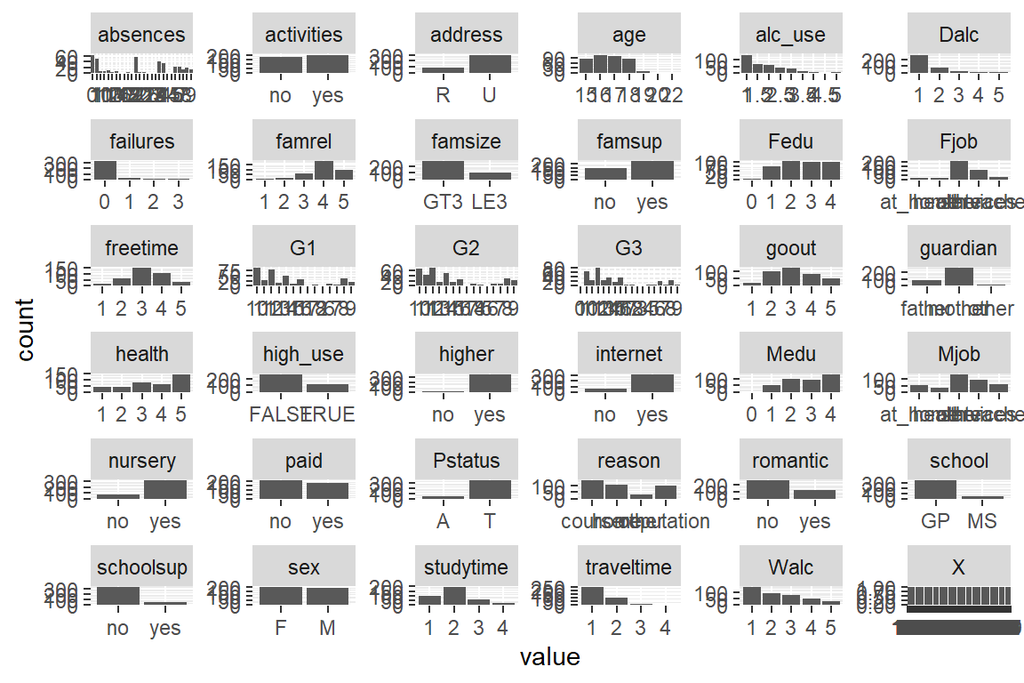

```r
alc1 <- gather(alc) %>% ggplot(aes(value)) + facet_wrap("key", scales = "free")
alc1 + geom_bar()
```

This data approach student achievement in secondary education of two Portuguese schools and the variables include student grades, demographic, social and school related features. In my analysis here my task is to study witch variables affect students consumption of alcohol and predict it. My hypothesis is that studytime relates to alcohol consumption so that the more you drink the less time you study. Alcohol consumption could also have something to do with failures and absences. My guess is also that bad familyrelations could encrease alcohol consumption.

**Barplot of alcohol consumption by sex**

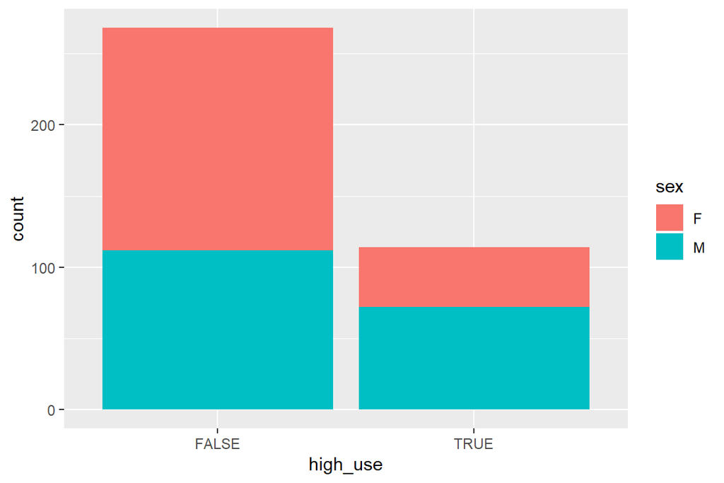

```r
g1 <- ggplot(data = alc, aes(x = high_use, fill = sex))
g1 + geom_bar()
```

**Ggplot of alcohol consumption**

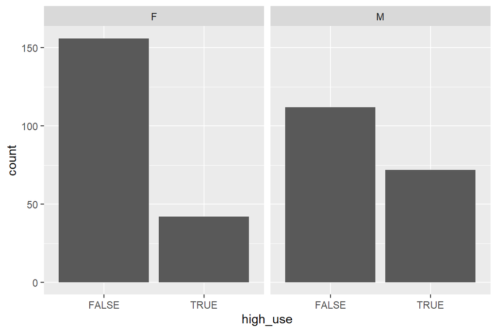

```r
g2 <- ggplot(data = alc, aes(x = high_use))
g3 <- g2 + geom_bar()
g4 <- g3 + facet_wrap("sex")
g4
```

**The distribution of familyrelations and alcohol consumption**

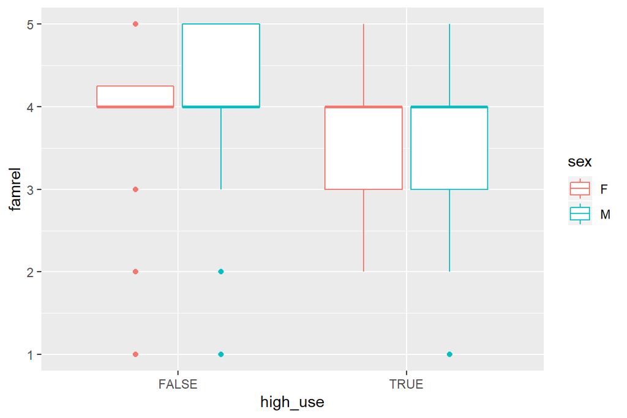

```r
g1 <- ggplot(alc, aes(x = high_use, y = famrel,col = sex))
g1 + geom_boxplot() + ylab("famrel")
```

```r
alc %>% group_by(sex, high_use, famrel) %>% summarise(count = n())
```

```
## # A tibble: 19 x 4
## # Groups:   sex, high_use [4]
##    sex   high_use famrel count
##    <fct> <lgl>     <int> <int>
##  1 F     FALSE         1     5
##  2 F     FALSE         2     7
##  3 F     FALSE         3    24
##  4 F     FALSE         4    81
##  5 F     FALSE         5    39
##  6 F     TRUE          2     3
##  7 F     TRUE          3    12
##  8 F     TRUE          4    19
##  9 F     TRUE          5     8
## 10 M     FALSE         1     1
## 11 M     FALSE         2     3
## 12 M     FALSE         3    15
## 13 M     FALSE         4    54
## 14 M     FALSE         5    39
## 15 M     TRUE          1     2
## 16 M     TRUE          2     6
## 17 M     TRUE          3    13
## 18 M     TRUE          4    35
## 19 M     TRUE          5    16
```